# Proyecto final

### **Estimación de diversidad alfa**

La diversidad alfa hace posible la estimación de la magnitud de diversidad en una muestra, y permite realizar análisis sobre la distribución y abundancia de disntintos taxones en la misma. Existen muchos índices que describen qué tan distintas o heterogeneas son las comunidades, y algunos (como Chao1) parten de la valoración de presencia o ausencia de especies raras en las mismas (singletons y doubletons).

El índice de Shannon es una métrica ampliamente utilizada para calcular que tan uniforme es una muestra o comunidad; entre más cercano a 0 sea su valor, puede decirse que se trata de una comunidad con tendencia a ser homogénea, esto es, que su diversidad es poca o nula. Mientras que entre más alto sea su valor, más diversidad hay en la comunidad.

El estimador de Chao1 se basa en la presencia de singletons, es decir, indica cuántos singletons y doubletons hay en una muestra.

El índice de Simpson representa la probabilidad de que si se seleccionan dos individuos pertecientes a una misma comunidad , estos pertenezcan a la misma especie. Entre más alto sea el índice de Simpson, menos diversa es una comunidad.

A continuación, se estima la diversidad alfa mediante el índice de shannon , el estimador de Chao1, y el índice de simpson, para comparar la diversidad microbiana presente en el intestino de gatos domésticos parasitados por *T. cati* en contraste con la diversidad microbiana en el intestino de gatos sanos.

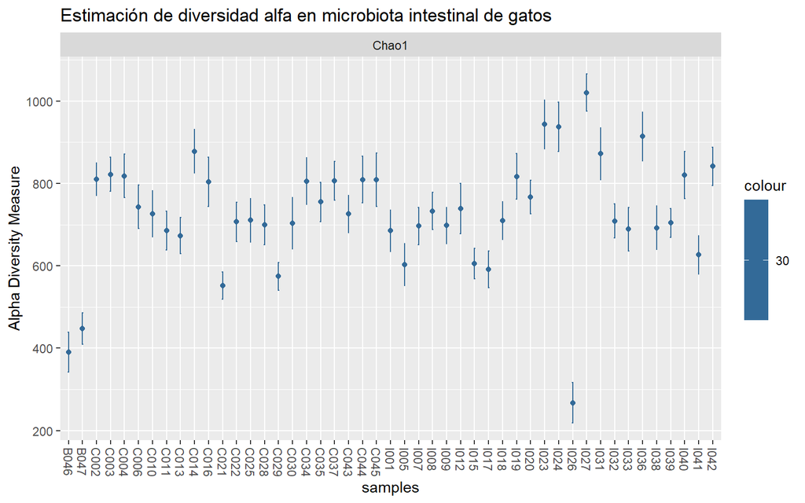

```r
plot_richness(ar, measures=c("Chao1"), title = "Estimación de diversidad alfa en microbiota intestinal de gatos", color =30)
```

```r
#tabla de estimado de Chao1
richness <- estimate_richness(ar,measures = "Chao1")
richness
```

```
##          Chao1 se.chao1
## B047  447.4419 38.67368
## B046  390.2000 47.94791
## I042  841.8800 46.57174
## I041  626.3860 45.86715
## I040  820.5000 56.75460
## I039  704.0330 34.89978
## I038  692.1695 52.82498
## I036  914.1370 59.27217
## I033  688.7000 53.24810
## I032  709.0143 41.16973
## I031  872.0476 62.80865
## I027 1020.2500 45.20419
## I026  267.4000 49.03910
## I024  937.5000 59.82012
## I023  943.5000 59.42727
## I020  767.0000 40.33620
## I019  816.8182 55.18973
## I018  709.5857 46.05286
## I017  590.9811 44.64374
## I015  605.5000 36.53649
## I012  739.3684 60.87675
## I009  698.1538 43.83202
## I008  732.7273 45.23006
## I007  696.8154 45.13234
## I005  603.0204 51.04633
## I001  685.1207 50.32257
## C045  808.7778 64.83207
## C044  809.0462 56.64397
## C043  725.6522 45.11399
## C037  806.3000 47.31265
## C035  755.1268 47.40215
## C034  805.3043 56.57248
## C030  703.6222 62.14248
## C029  574.4179 33.33177
## C028  699.2308 48.23407
## C025  710.5000 52.44525
## C022  706.5082 47.53046
## C021  552.2206 32.80425
## C016  804.2381 59.72391
## C010  726.3962 55.79429
## C011  685.8033 47.06357
## C013  673.3731 43.63329
## C004  818.1642 52.86691
## C002  809.8659 39.73088
## C006  743.2542 52.32271
## C014  877.8750 52.58884
## C003  822.1625 41.17488
```

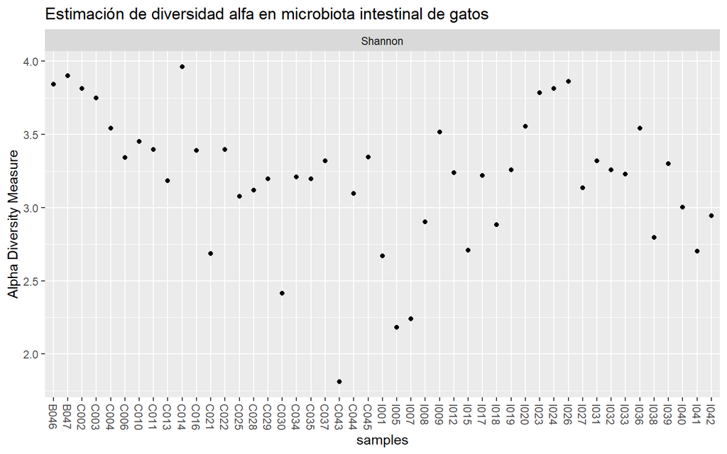

```r
plot_richness(ar, measures=c("Shannon"), title = "Estimación de diversidad alfa en microbiota intestinal de gatos")
```

```r
#tabla de estimado de índice de Shannon
richness.sh<-estimate_richness(ar, measures="shannon")
richness.sh
```

```
##       Shannon
## B047 3.901035
## B046 3.844762
## I042 2.943787
## I041 2.701717
## I040 3.004357
## I039 3.300245
## I038 2.796055
## I036 3.542435
## I033 3.229345
## I032 3.257704
## I031 3.319793
## I027 3.134527
## I026 3.863942
## I024 3.815214
## I023 3.784295
## I020 3.556780
## I019 3.259515
## I018 2.883014
## I017 3.218089
## I015 2.708147
## I012 3.237856
## I009 3.517098
## I008 2.903449
## I007 2.240840
## I005 2.181788
## I001 2.670824
## C045 3.344624
## C044 3.095094
## C043 1.809818
## C037 3.320545
## C035 3.196359
## C034 3.208825
## C030 2.414982
## C029 3.196653
## C028 3.118430
## C025 3.075943
## C022 3.396000
## C021 2.686470
## C016 3.391369
## C010 3.453187
## C011 3.398526
## C013 3.183739
## C004 3.543784
## C002 3.815434
## C006 3.340702
## C014 3.961521
## C003 3.749333
```

En cuanto al índice de Shannon, se puede observar que las muestras correspondientes a los controles negativos y gatos de bioterio, en su mayoría, tienen un índice de Shannon igual o mayor a tres. Por otra parte, los gatos infectados por T. cani poseen índices de Shannon más pequeños. En realidad, parece ser que, salvo algunas excepciones, la mayoría de las muestras tienen índices mayores a tres.

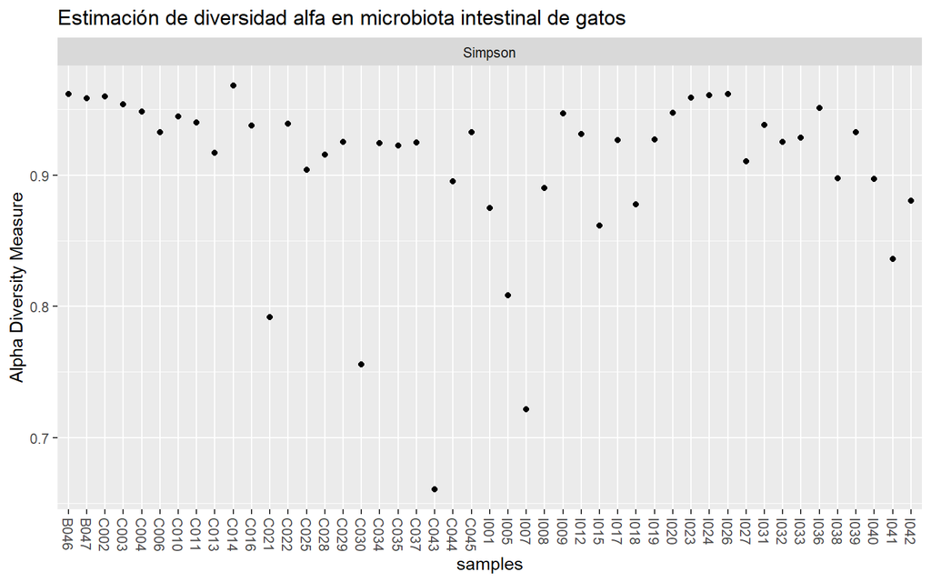

```r
plot_richness(ar, measures=c("simpson"), title = "Estimación de diversidad alfa en microbiota intestinal de gatos")
```

```r
#tabla de estimado de índice de simpson
richness.sp<-estimate_richness(ar, measures = "simpson")
richness.sp
```

```
##        Simpson
## B047 0.9584412
## B046 0.9617883
## I042 0.8803873
## I041 0.8358984
## I040 0.8969654
## I039 0.9327500
## I038 0.8974510
## I036 0.9510699
## I033 0.9282794
## I032 0.9252389
## I031 0.9379841
## I027 0.9104126
## I026 0.9615985
## I024 0.9605895
## I023 0.9587241
## I020 0.9476246
## I019 0.9271154
## I018 0.8777084
## I017 0.9268027
## I015 0.8613104
## I012 0.9314219
## I009 0.9467744
## I008 0.8903170
## I007 0.7215933
## I005 0.8084533
## I001 0.8747567
## C045 0.9324405
## C044 0.8952330
## C043 0.6605273
## C037 0.9246518
## C035 0.9222468
## C034 0.9242462
## C030 0.7555900
## C029 0.9252401
## C028 0.9155253
## C025 0.9038668
## C022 0.9392871
## C021 0.7918066
## C016 0.9375233
## C010 0.9448449
## C011 0.9399121
## C013 0.9169128
## C004 0.9484355
## C002 0.9596879
## C006 0.9326123
## C014 0.9679992
## C003 0.9537943
```